# The Detection Process

Peter Solymos solymos@ualberta.ca

## Introduction

As part of the detection process, a skilled observer counts individual birds at a count station. New individuals are assigned to time and distance categories, the type of behavior also registered. During this process, auditory cues travel through the distance between the bird and the observer. As the pover of the sound fades away, the chanches of being detected also decreases. If the detection process is based on visual detections, vegetation can block line of sight, etc. In this chapter, we scrutinize how this detection process contributes to the factor $C$.

## Prerequisites

```r
library(bSims)                # simulations
```

```
## mefa4 0.3-7   2020-02-28
```

```
## deldir 0.2-10      Nickname: "Morpheus and Euripides"
```

[output not shown]

```
## bSims 0.2-3   2021-03-15      kitty-waaak
```

```r
library(detect)               # multinomial models
```

```
## detect 0.4-4      2020-08-12
```

```r
library(Distance)             # distance sampling
load("data/josm-data.rda")   # JOSM data
source("src/functions.R")         # some useful stuff
```

## Distance functions

The distance function ($g(d)$ describes the probability of detecting an individual given the distance between the observer and the individual ($d$). The detection itself is often triggered by visual or auditory cues, and thus depend on the individuals being available for detection (and of course being present in the survey area).

Distance functions have some characteristics:

- It is a monotonic decreasing function of distance,
- $g(0)=1$: detection at 0 distance is perfect.

Here are some common distance function and rationale for their use (i.e. mechanisms leading to such distance shapes):

1. Negative Exponential: a one-parameter function ($g(d) = e^{-d/\tau}$), probability quickly decreases with distance, this mirrors sound attenuation under spherical spreading, so might be a suitable form for acoustic recording devices (we will revisit this later), but not a very useful form for human based counts, as explained below;
2. Half-Normal: this is also a one-parameter function ($g(d) = e^{-(d/\tau)^2}$) where probability initially remain high (the *shoulder*), reflecting an increased chance of detecting individuals closer to the observer, this form has also sone practical advantages that we will discuss shortly ($\tau^2$ is variance of the unfolded Normal distribution, $\tau^2/2$ is the variance of the Half-Normal distribution – both the Negative Exponential and the Half-Normal being special cases of $g(d) = e^{-(d/\tau)^b}$ that have the parameter $b$ [$b > 0$] affecting the shoulder);
3. Hazard rate: this is a two-parameter model ($g(d) = 1-e^{-(d/\tau)^-b}$) that have the parameter $b$ ($b > 0$) affecting the more pronounced and sharp shoulder.

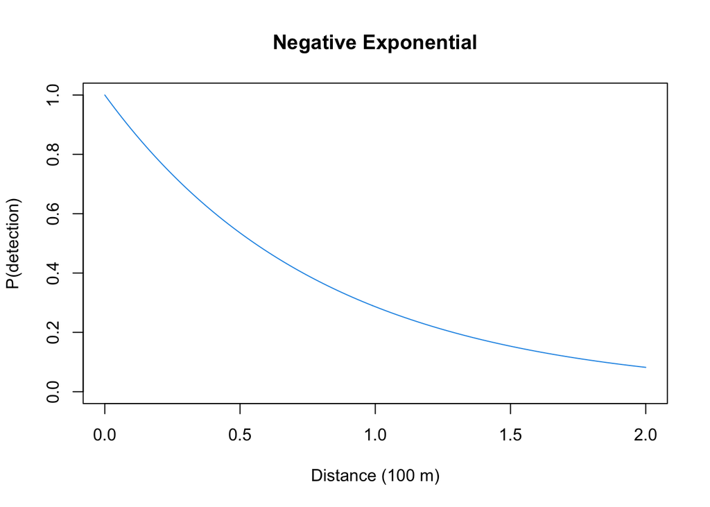

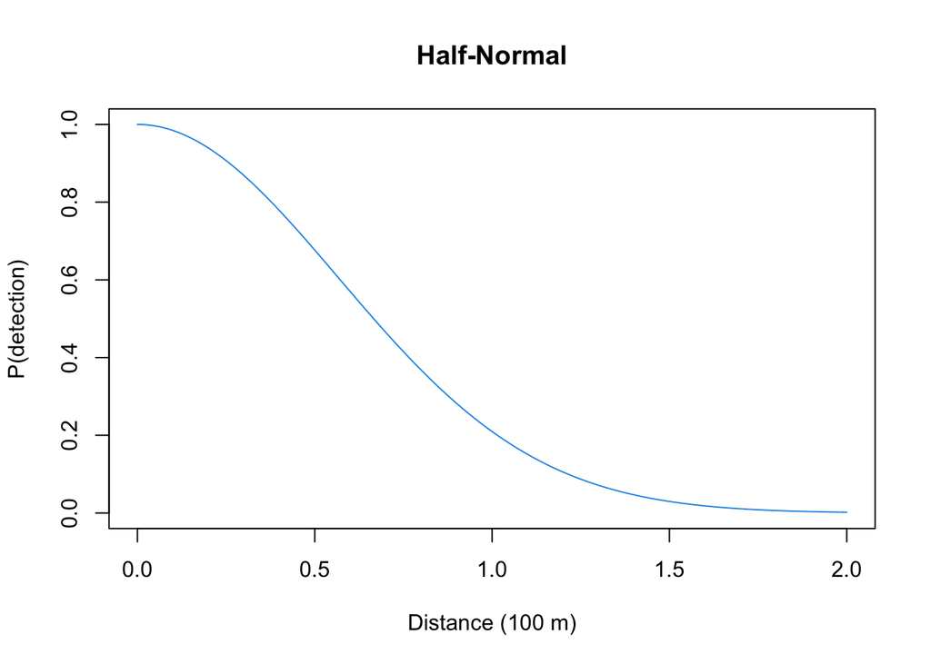

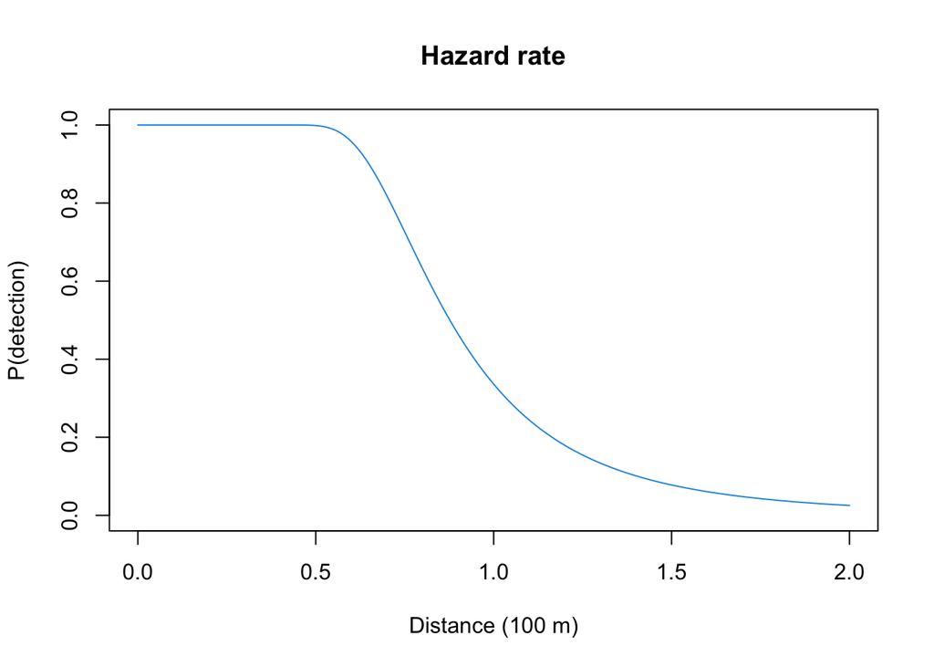

```r
d <- seq(0, 2, 0.01)
plot(d, exp(-d/0.8), type="l", col=4, ylim=c(0,1),
  xlab="Distance (100 m)", ylab="P(detection)", main="Negative Exponential")
plot(d, exp(-(d/0.8)^2), type="l", col=4, ylim=c(0,1),
  xlab="Distance (100 m)", ylab="P(detection)", main="Half-Normal")
plot(d, 1-exp(-(d/0.8)^-4), type="l", col=4, ylim=c(0,1),
  xlab="Distance (100 m)", ylab="P(detection)", main="Hazard rate")
```

## Exercise

Try different values of $b$ to explore the different shapes of the Hazard rate function.

Write your own code (`plot(d, exp(-(d/<tau>)^<b>), type="l", ylim=c(0,1))`), or run `bSims::run_app("distfunH")`.

```r
d <- seq(0, 2, 0.01)
tau <- 1
b <- 1

plot(d, exp(-(d/tau)^b), type="l", ylim=c(0,1))

bSims::run_app("distfunH")
```

As we saw before, the Shiny app can be used to copy the distance function that we can use later in our simulations.

## Simulations

We will apply this new found knowledge to our bSims world: the observer is in the middle of the landscape, and each vocalization event is aither detected or not, depending on the distance. Units of `tau` are given on 100 m units, so that corresponding density estimates will refer to ha as the unit area.

In this example, we want all individuals to be equally available, so we are going to override all behavioral aspects of the simulations by the `initial_location` argument when calling `bsims_animate`. We set `density` and `tau` high enough to get many detections in this example.

```r
tau <- 2

set.seed(123)
l <- bsims_init()
a <- bsims_populate(l, density=10)
b <- bsims_animate(a, initial_location=TRUE)

(o <- bsims_detect(b, tau=tau))
```

```
## bSims detections
##   1 km x 1 km
##   stratification: H
##   total abundance: 1013
##   no events, duration: 10 min
##   detected: 128 heard
```

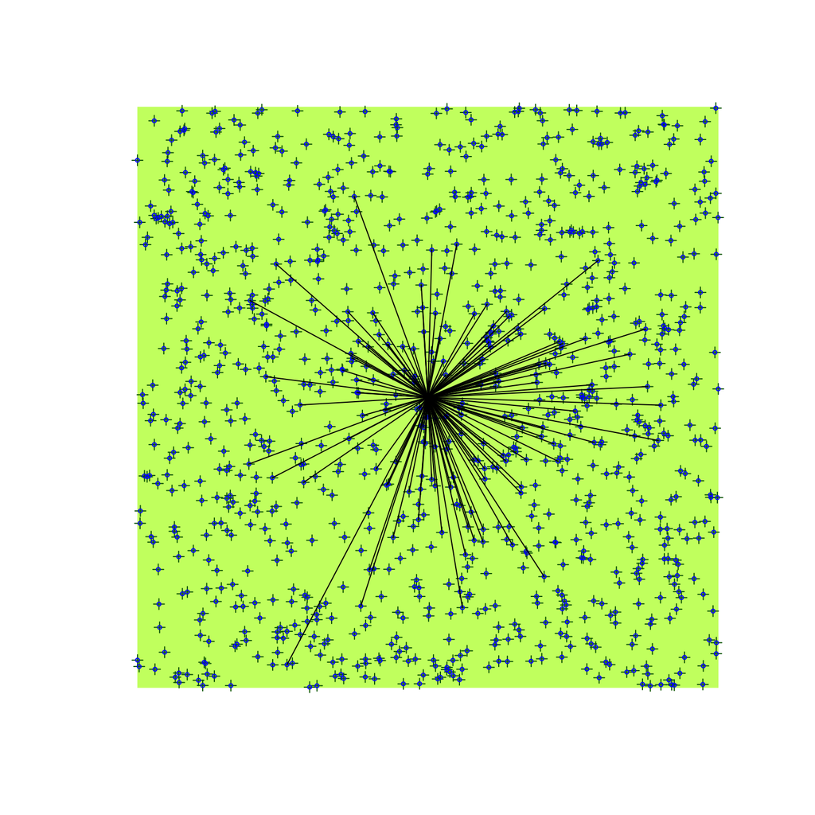

```r
plot(o)
```

## Distance sampling

The distribution of the *observed distances* is a product of detectability and the distribution of the individuals with respect to the point where the observer is located. For point counts, area increases linearly with radial distance, implying a triangular distribution with respect to the point ($h(d)=\pi 2 d /A=\pi 2 d / \pi r_{max}^2=2 d / r_{max}^2$, where $A$ is a circular survey area with truncation distance $r_{max}$). The product $g(d) h(d)$ gives the density function of the observed distances.

```r
g <- function(d, tau, b=2, hazard=FALSE)
  if (hazard)
    1-exp(-(d/tau)^-b) else exp(-(d/tau)^b)
h <- function(d, rmax)
  2*d/rmax^2
```

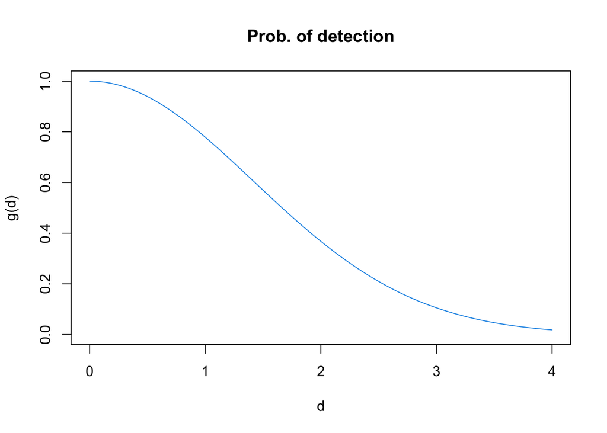

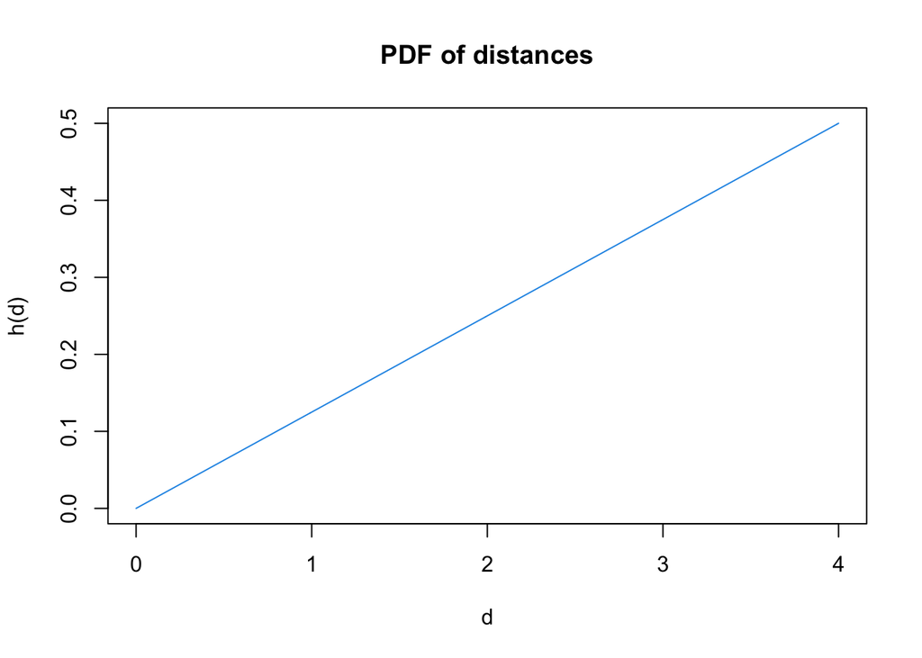

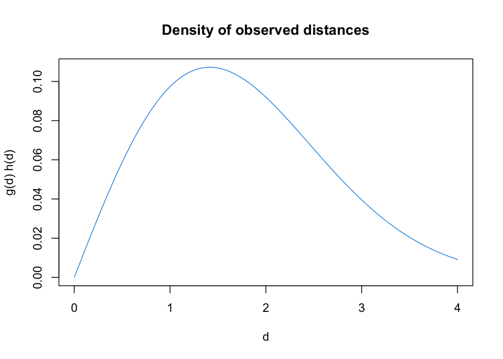

```r
rmax <- 4

d <- seq(0, rmax, 0.01)
plot(d, g(d, tau), type="l", col=4, ylim=c(0,1),
  xlab="d", ylab="g(d)", main="Prob. of detection")
plot(d, h(d, rmax), type="l", col=4,
  xlab="d", ylab="h(d)", main="PDF of distances")
plot(d, g(d, tau) * h(d, rmax), type="l", col=4,
  xlab="d", ylab="g(d) h(d)", main="Density of observed distances")
```

The object `da` contains the distances to all the nests based on our bSims object, we use this to display the distribution of available distances:

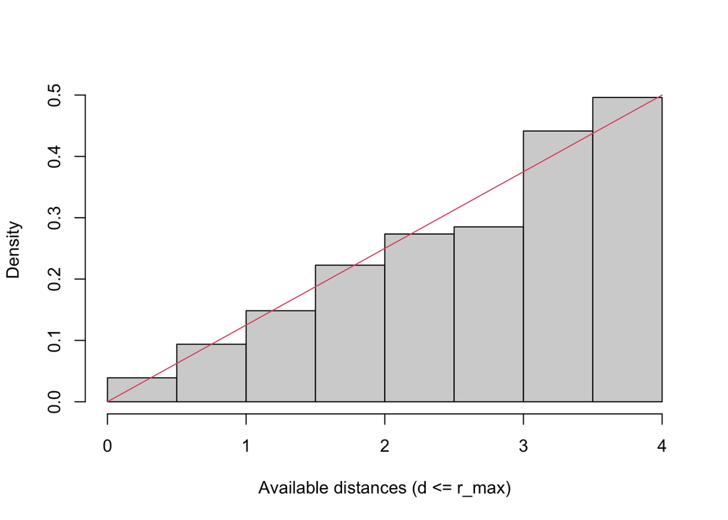

```r
da <- sqrt(rowSums(a$nests[,c("x", "y")]^2))

hist(da[da <= rmax], freq=FALSE, xlim=c(0, rmax),
  xlab="Available distances (d <= r_max)", main="")
curve(2*x/rmax^2, add=TRUE, col=2)
```

The `get_detections` function returns a data frame with the detected events (in our case just the nest locations): `$d` is the distance.

```r
head(dt <- get_detections(o))
```

```
##              x          y t v         d  i  j
## 9  -2.13683299 -1.4639392 0 1 2.5902072  9  9
## 15 -0.22748175  0.3605372 0 1 0.4263039 15 15
## 19 -0.02865112 -0.3528623 0 1 0.3540235 19 19
## 45 -0.71086142 -1.5128051 0 1 1.6714973 45 45
## 47 -2.78899963  0.3554139 0 1 2.8115544 47 47
## 58 -3.08015181 -1.1482640 0 1 3.2872246 58 58
```

The following piece of code plots the probability density of the observed distances within the truncation distance $r_{max}$, thus we need to standardize the $g(r) h(r)$ function by the sum of the integral:

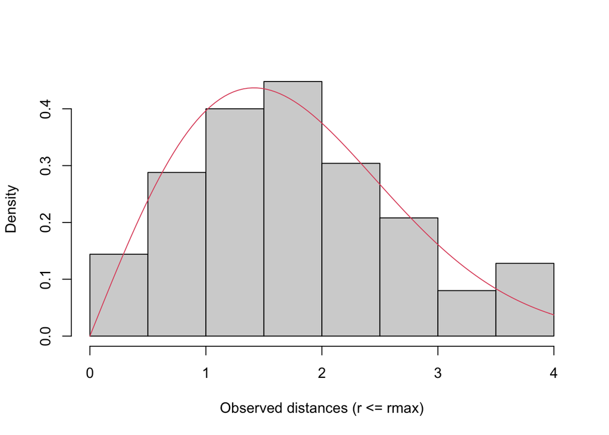

```r
f <- function(d, tau, b=2, hazard=FALSE, rmax=1)
  g(d, tau, b, hazard) * h(d, rmax)
tot <- integrate(f, lower=0, upper=rmax, tau=tau, rmax=rmax)$value

hist(dt$d[dt$d <= rmax], freq=FALSE, xlim=c(0, rmax),
  xlab="Observed distances (r <= rmax)", main="")
curve(f(x, tau=tau, rmax=rmax) / tot, add=TRUE, col=2)
```

In case of the Half-Normal, we can linearize the relationship by taking the log of the distance function: $log(g(d)) =log(e^{-(d/\tau)^2})= -(d / \tau)^2 = x \frac{1}{\tau^2} = 0 + x \beta$. Consequently, we can use GLM to fit a model with $x = -d^2$ as predictor and no intercept, and estimate $\hat{\beta}$ and $\hat{\tau}=\sqrt{1/\hat{\beta}}$.

For this method to work, we need to know the observed and unobserved distances as well, which makes this approach of low utility in practice when location of unobserved individuals is unknown. But we can at least check our bSims data:

```r
dat <- data.frame(
  distance=da,
  x=-da^2,
  detected=ifelse(rownames(o$nests) %in% dt$i, 1, 0))
summary(dat)
```

```
##     distance            x                detected
##  Min.   :0.2264   Min.   :-49.33230   Min.   :0.0000
##  1st Qu.:2.8758   1st Qu.:-23.73953   1st Qu.:0.0000
##  Median :3.9653   Median :-15.72398   Median :0.0000
##  Mean   :3.8274   Mean   :-16.68895   Mean   :0.1264
##  3rd Qu.:4.8723   3rd Qu.: -8.27033   3rd Qu.:0.0000
##  Max.   :7.0237   Max.   : -0.05125   Max.   :1.0000
```

```r
mod <- glm(detected ~ x - 1, data=dat, family=binomial(link="log"))
c(true=tau, estimate=sqrt(1/coef(mod)))
```

```
##       true estimate.x
##   2.000000   2.034018
```

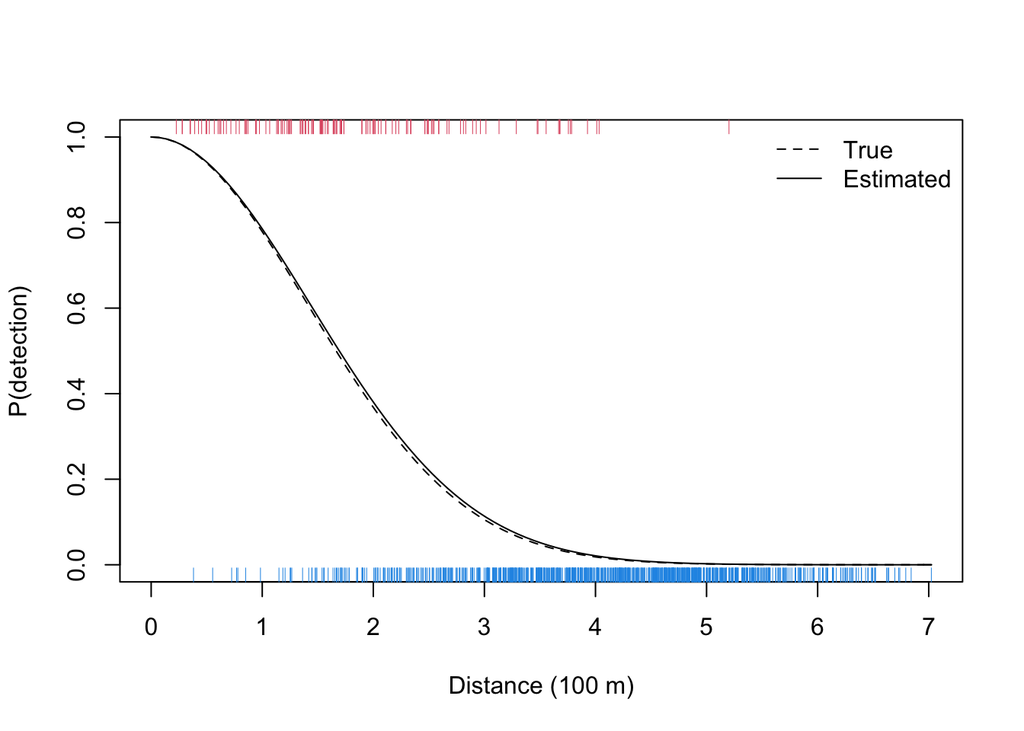

```r
curve(exp(-(x/sqrt(1/coef(mod)))^2),
  xlim=c(0,max(dat$distance)), ylim=c(0,1),
  xlab="Distance (100 m)", ylab="P(detection)")
curve(exp(-(x/tau)^2), lty=2, add=TRUE)
rug(dat$distance[dat$detected == 0], side=1, col=4)
rug(dat$distance[dat$detected == 1], side=3, col=2)
legend("topright", bty="n", lty=c(2,1),
  legend=c("True", "Estimated"))
```

The Distance package offers various tools to fit models to observed distance data. See [here](https://workshops.distancesampling.org/duke-spatial-2015/practicals/1-detection-functions-solutions.html) for a tutorial. The following script fits the Half-Normal (`key = "hn"`) without ajustments (`adjustment=NULL`) to observed distance data from truncated point transect. It estimates $\sigma = \sqrt{\tau}$:

```r
dd <- ds(dt$d, truncation = rmax, transect="point",
  key = "hn", adjustment=NULL)
```

```
## Fitting half-normal key function
```

```
## Key only model: not constraining for monotonicity.
```

```
## AIC= 315.502
```

```
## No survey area information supplied, only estimating detection function.
```

```r
c(true=tau, estimate=exp(dd$ddf$par)^2)
```

```
##     true estimate
## 2.000000 2.175567
```

**BREAK**

## Average detection

To calculate the average probability of detecting individuals within a circle with truncation distance $r_{max}$, we need to integrate over the product of $g(r)$ and $h(r)$: $q(r_{max})=\int_{0}^{r_{max}} g(d) h(d) dd$. This gives the volume of pie dough cut at $r_{max}$, compared to the volume of the cookie cutter ($\pi r_{max}^2$).

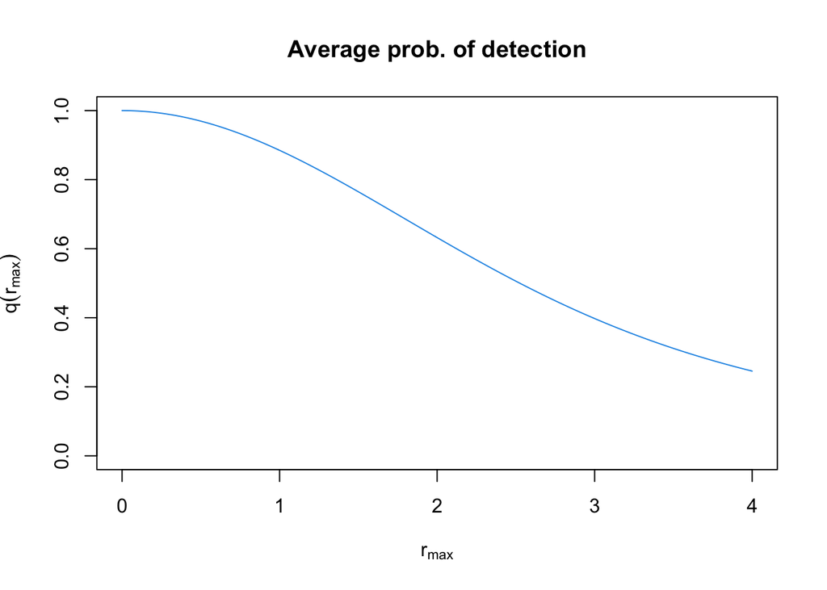

```r
q <- sapply(d[d > 0], function(z)
  integrate(f, lower=0, upper=z, tau=tau, rmax=z)$value)

plot(d, c(1, q), type="l", col=4, ylim=c(0,1),
  xlab=expression(r[max]), ylab=expression(q(r[max])),
  main="Average prob. of detection")
```

For the Half-Normal detection function, the analytical solution for the average probability is $\pi \tau^2 [1-exp(-d^2/\tau^2)] / (\pi r_{max}^2)$, where the denominator is a normalizing constant representing the volume of a cylinder of perfect detectability.

To visualize this, here is the pie analogy for $\tau=2$ and $r_{max}=2$:

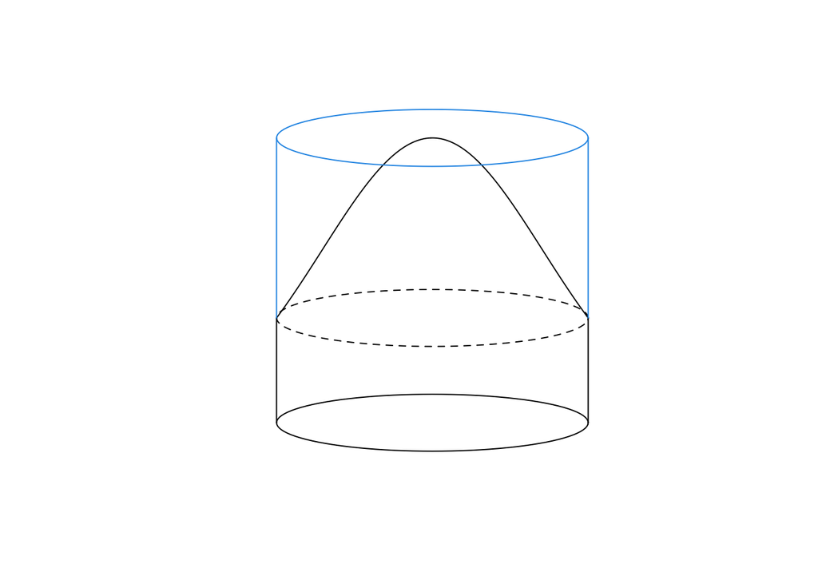

```r
tau <- 2
rmax <- 2
w <- 0.1
m <- 2
plot(0, type="n", xlim=m*c(-rmax, rmax), ylim=c(-w, 1+w),
  axes=FALSE, ann=FALSE)
yh <- g(rmax, tau=tau)
lines(seq(-rmax, rmax, rmax/100),
  g(abs(seq(-rmax, rmax, rmax/100)), tau=tau))
draw_ellipse(0, yh, rmax, w, lty=2)
lines(-c(rmax, rmax), c(0, yh))
lines(c(rmax, rmax), c(0, yh))
draw_ellipse(0, 0, rmax, w)
draw_ellipse(0, 1, rmax, w, border=4)
lines(-c(rmax, rmax), c(yh, 1), col=4)
lines(c(rmax, rmax), c(yh, 1), col=4)
```

## Binned distances

The cumulative density function for the Half-Normal distribution ($\pi(r) = 1-e^{-(r/\tau)^2}$) is used to calculate cell probabilities for binned distance data (the normalizing constant is the area of the integral $\pi \tau^2$, instead of $\pi r_{max}^2$). It captures the proportion of the observed distances relative to the whole volume of the observed distance density. In the pie analogy, this is the dough volume inside the cookie cutter, compared to the dough volume inside and outside of the cutter (that happens to be $\pi \tau^2$ for the Half-Normal):

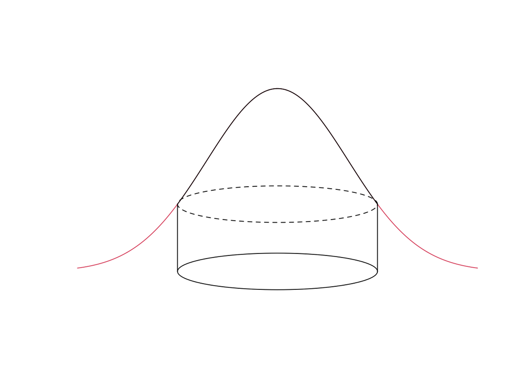

```r
plot(0, type="n", xlim=m*c(-rmax, rmax), ylim=c(-w, 1+w),
  axes=FALSE, ann=FALSE)
yh <- g(rmax, tau=tau)
lines(seq(-m*rmax, m*rmax, rmax/(m*100)),
  g(seq(-m*rmax, m*rmax, rmax/(m*100)), tau=tau),
  col=2)
lines(seq(-rmax, rmax, rmax/100),
  g(abs(seq(-rmax, rmax, rmax/100)), tau=tau))
draw_ellipse(0, yh, rmax, w, lty=2)
lines(-c(rmax, rmax), c(0, yh))
lines(c(rmax, rmax), c(0, yh))
draw_ellipse(0, 0, rmax, w)
```

In case of the Half-Normal distance function, $\tau$ is the *effective detection radius* (EDR). The effective detection radius is the distance from observer where the number of individuals missed within EDR (volume of ‘air’ in the cookie cutter above the dough) equals the number of individuals detected outside of EDR (dough volume outside the cookie cutter), EDR is the radius $r_e$ where $q(r_e)=\pi(r_e)$:

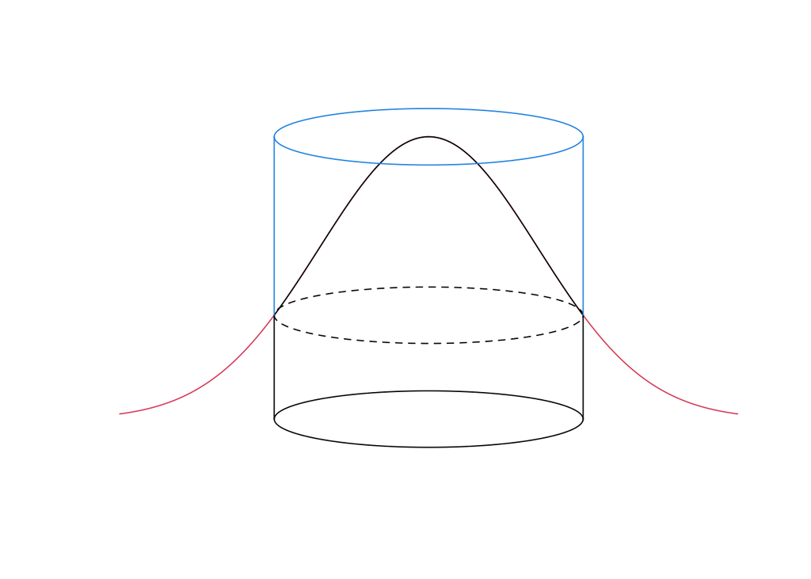

```r
plot(0, type="n", xlim=m*c(-rmax, rmax), ylim=c(-w, 1+w),
  axes=FALSE, ann=FALSE)
yh <- g(rmax, tau=tau)
lines(seq(-m*rmax, m*rmax, rmax/(m*100)),
  g(seq(-m*rmax, m*rmax, rmax/(m*100)), tau=tau),
  col=2)
lines(seq(-rmax, rmax, rmax/100),
  g(abs(seq(-rmax, rmax, rmax/100)), tau=tau))
draw_ellipse(0, yh, rmax, w, lty=2)
lines(-c(rmax, rmax), c(0, yh))
lines(c(rmax, rmax), c(0, yh))
draw_ellipse(0, 0, rmax, w)
draw_ellipse(0, 1, rmax, w, border=4)
lines(-c(rmax, rmax), c(yh, 1), col=4)
lines(c(rmax, rmax), c(yh, 1), col=4)
```

## Exercise

What would be a computational algorithm to calculate EDR for any distance function and truncation distance?

Try to explain how the code below is working.

Why are EDRs different for different truncation distances?

```r
find_edr <- function(dist_fun, ..., rmax=Inf) {
  ## integral function
  f <- function(d, ...)
    dist_fun(d, ...) * 2*d*pi
  ## volume under dist_fun
  V <- integrate(f, lower=0, upper=rmax, ...)$value
  u <- function(edr)
    V - edr^2*pi
  uniroot(u, c(0, 1000))$root
}

find_edr(g, tau=1)
```

```
## [1] 0.9999999
```

```r
find_edr(g, tau=10)
```

```
## [1] 10
```

```r
find_edr(g, tau=1, b=1)
```

```
## [1] 1.414208
```

```r
find_edr(g, tau=1, b=4, hazard=TRUE)
```

```
## [1] 1.331326
```

```r
find_edr(g, tau=1, rmax=1)
```

```
## [1] 0.7950578
```

The function $\pi(r)$ increases monotonically from 0 to 1:

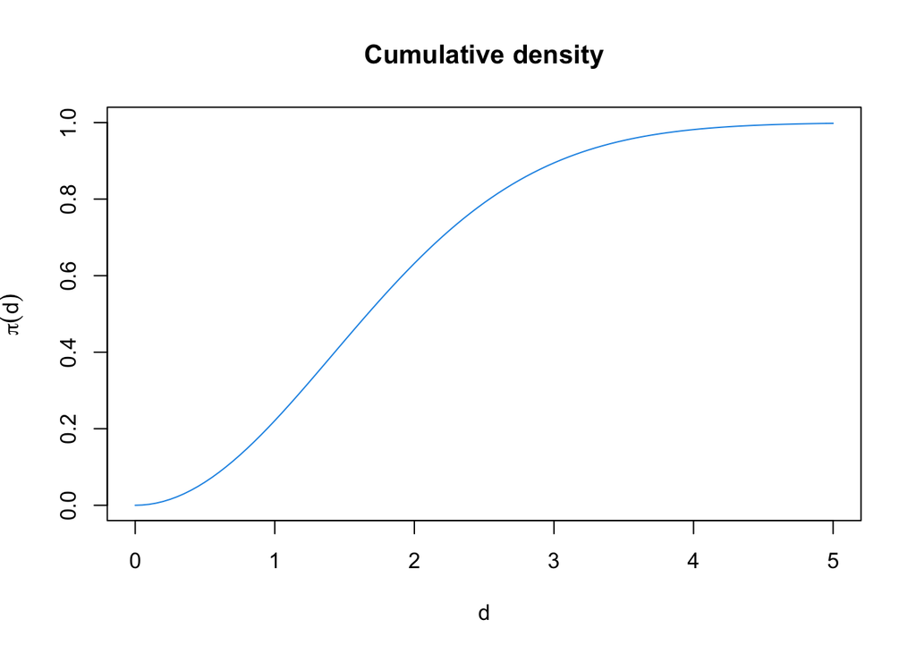

```r
curve(1-exp(-(x/tau)^2), xlim=c(0, 5), ylim=c(0,1), col=4,
  ylab=expression(pi(d)), xlab=expression(d),
  main="Cumulative density")
```

Here are binned distances for the bSims data, with expected proportions based on $\pi()$ cell probabilities (differences within the distance bins). The nice thing about this cumulative density formulation is that it applies equally to truncated and unlimited (not truncated) distance data, and the radius end point for a bin (stored in `br`) can be infinite:

```r
br <- c(1, 2, 3, 4, 5, Inf)
dat$bin <- cut(da, c(0, br), include.lowest = TRUE)
(counts <- with(dat, table(bin, detected)))
```

```
##          detected
## bin         0   1
##   [0,1]     7  27
##   (1,2]    42  53
##   (2,3]   111  32
##   (3,4]   227  13
##   (4,5]   287   2
##   (5,Inf] 211   1
```

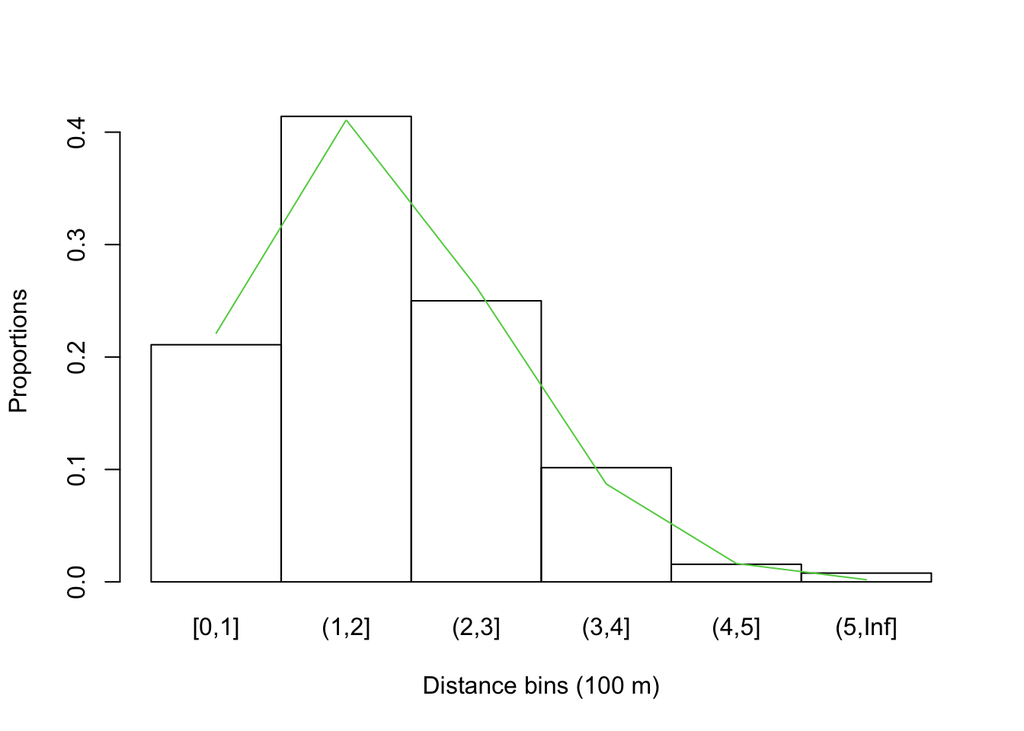

```r
pi_br <- 1-exp(-(br/tau)^2)

barplot(counts[,"1"]/sum(counts[,"1"]), space=0, col=NA,
  xlab="Distance bins (100 m)", ylab="Proportions",
  ylim=c(0, max(diff(c(0, pi_br)))))
lines(seq_len(length(br))-0.5, diff(c(0, pi_br)), col=3)
```

We can use the `bsims_transcribe` function for the same effect, and estimate $\hat{\tau}$ based on the binned data:

```r
(tr <- bsims_transcribe(o, rint=br))
```

```
## bSims transcript
##   1 km x 1 km
##   stratification: H
##   total abundance: 1013
##   no events, duration: 10 min
##   detected: 128 heard
##   1st event detected by breaks:
##     [0, 10 min]
##     [0, 100, 200, 300, 400, 500, Inf m]
```

```r
tr$removal
```

```
##          0-10min
## 0-100m        27
## 100-200m      53
## 200-300m      32
## 300-400m      13
## 400-500m       2
## 500+m          1
```

```r
Y <- matrix(drop(tr$removal), nrow=1)
D <- matrix(br, nrow=1)

tauhat <- exp(cmulti.fit(Y, D, type="dis")$coef)

c(true=tau, estimate=tauhat)
```

```
##     true estimate
## 2.000000 2.067061
```

Here are cumulative counts and the true and expected cumulative cell probabilities:

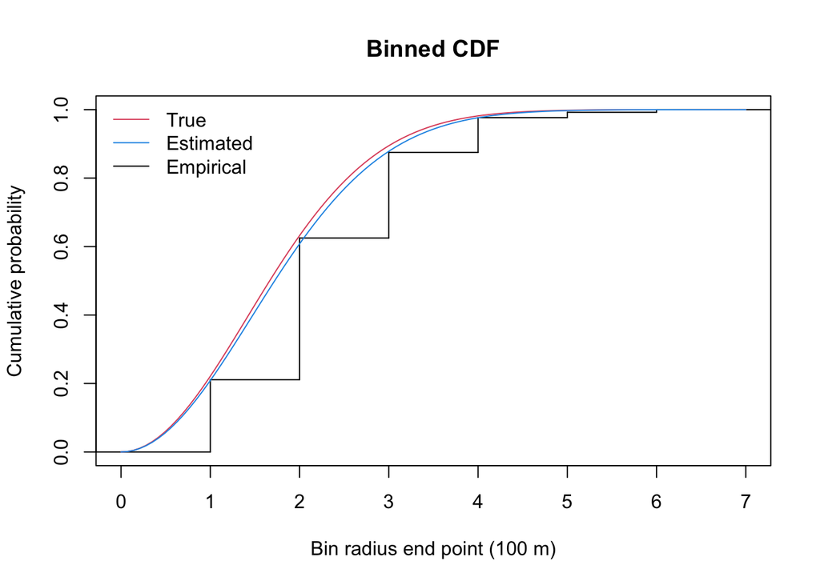

```r
plot(stepfun(1:6, c(0, cumsum(counts[,"1"])/sum(counts[,"1"]))),
  do.points=FALSE, main="Binned CDF",
  ylab="Cumulative probability",
  xlab="Bin radius end point (100 m)")
curve(1-exp(-(x/tau)^2), col=2, add=TRUE)
curve(1-exp(-(x/tauhat)^2), col=4, add=TRUE)
legend("topleft", bty="n", lty=1, col=c(2, 4, 1),
  legend=c("True", "Estimated", "Empirical"))
```

## Availability bias

We have ignored availability so far when working with bSims, but can’t continue like that for real data. What this means, is that $g(0) < 1$, so detecting an individual 0 distance from the observer depends on an event (visual or auditory) that would trigger the detection. For example, if a perfectly camouflaged birds sits in silence, detection might be difficult. Movement, or a vocalization can, however, reveal the individual and its location.

The `phi` and `tau` values are at the high end of plausible values for songbirds. The `Den`sity value is exaggerated, but this way we will have enough counts to prove our points using bSims:

```r
phi <- 0.5
tau <- 2
Den <- 10
```

Now we go through the layers of our bSims world:

1. initiating the landscape,
2. populating the landscape by individuals,
3. breath life into the virtual birds and let them sing,
4. put in an observer and let the observation process begin.

```r
set.seed(4321)
l <- bsims_init()
a <- bsims_populate(l, density=Den)
b <- bsims_animate(a, vocal_rate=phi)
o <- bsims_detect(b, tau=tau)
```

Transcription is the process of turning the detections into a table showing new individuals detected by time intervals and distance bands, as defined by the `tint` and `rint` arguments, respectively (ignore any errors in transcription for now).

```r
tint <- c(1, 2, 3, 4, 5)
rint <- c(0.5, 1, 1.5, 2) # truncated at 200 m
(tr <- bsims_transcribe(o, tint=tint, rint=rint))
```

```
## bSims transcript
##   1 km x 1 km
##   stratification: H
##   total abundance: 951
##   duration: 10 min
##   detected: 254 heard
##   1st event detected by breaks:
##     [0, 1, 2, 3, 4, 5 min]
##     [0, 50, 100, 150, 200 m]
```

```r
(rem <- tr$removal) # binned new individuals
```

```
##          0-1min 1-2min 2-3min 3-4min 4-5min
## 0-50m         3      2      1      0      0
## 50-100m       4      5      2      0      0
## 100-150m      5      9      7      3      3
## 150-200m      9      2      4      3      1
```

```r
colSums(rem)
```

```
## 0-1min 1-2min 2-3min 3-4min 4-5min
##     21     18     14      6      4
```

```r
rowSums(rem)
```

```
##    0-50m  50-100m 100-150m 150-200m
##        6       11       27       19
```

The plot method displays the detections presented as part of the `tr` object.

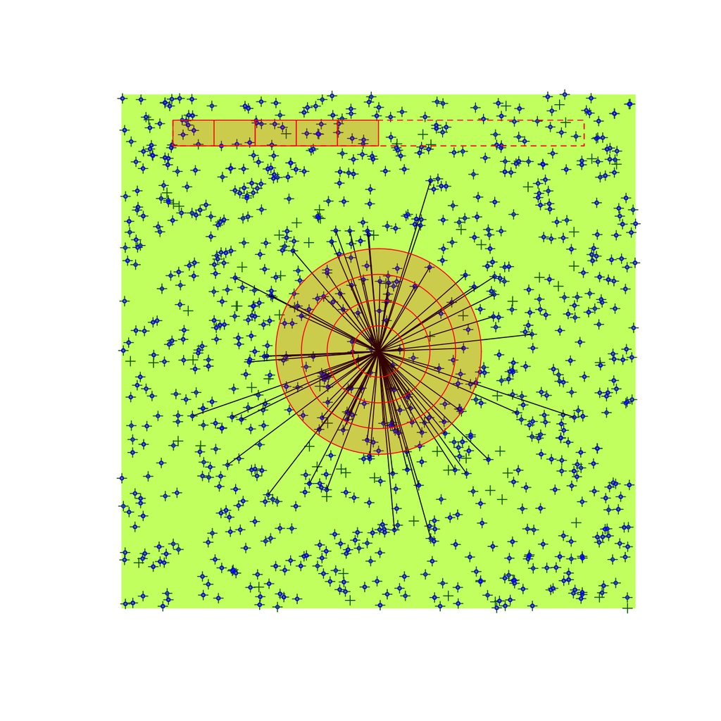

```r
plot(tr)
```

The detection process and the transcription (following a prescribed protocol) is inseparable in the field. However, recordings made in the field can be processed by a number of different ways. Separating these processed gives the ability to make these comparisons on the exact same set of detections.

## Estimating density with truncation

We now fit the removal model to the data pooled by time intervals. `p` is the cumulative probability of availability for the total duration:

```r
fitp <- cmulti.fit(matrix(colSums(rem), 1), matrix(tint, 1), type="rem")
phihat <- exp(fitp$coef)
c(true=phi, estimate=exp(fitp$coef))
```

```
##      true  estimate
## 0.5000000 0.3883786
```

```r
(p <- 1-exp(-max(tint)*phihat))
```

```
## [1] 0.8565678
```

The distance sampling model uses the distance binned counts, and a Half-Normal detection function, `q` is the cumulative probability of perceptibility within the area of truncation distance `rmax`:

```r
fitq <- cmulti.fit(matrix(rowSums(rem), 1), matrix(rint, 1), type="dis")
tauhat <- exp(fitq$coef)
c(true=tau, estimate=tauhat)
```

```
##     true estimate
## 2.000000 2.214674
```

```r
rmax <- max(rint)
(q <- (tauhat^2/rmax^2) * (1-exp(-(rmax/tauhat)^2)))
```

```
## [1] 0.6837211
```

The known `A`rea, `p`, and `q` together make up the correction factor, which is used to estimate density based on $\hat{D}=Y/(A \hat{p}\hat{q})$:

```r
(A <- pi * rmax^2)
```

```
## [1] 12.56637
```

```r
Dhat <- sum(rem) / (A * p * q)
c(true=Den, estimate=Dhat)
```

```
##      true  estimate
## 10.000000  8.560319
```

## Unlimited distance

We now change the distance bins to include the area outside of the previous `rmax` distance, making the counts to be unlimited distance counts:

```r
rint <- c(0.5, 1, 1.5, 2, Inf) # unlimited

(tr <- bsims_transcribe(o, tint=tint, rint=rint))
```

```
## bSims transcript
##   1 km x 1 km
##   stratification: H
##   total abundance: 951
##   duration: 10 min
##   detected: 254 heard
##   1st event detected by breaks:
##     [0, 1, 2, 3, 4, 5 min]
##     [0, 50, 100, 150, 200, Inf m]
```

```r
(rem <- tr$removal) # binned new individuals
```

```
##          0-1min 1-2min 2-3min 3-4min 4-5min
## 0-50m         3      2      1      0      0
## 50-100m       4      5      2      0      0
## 100-150m      5      9      7      3      3
## 150-200m      9      2      4      3      1
## 200+m        18      6      6      6      2
```

```r
colSums(rem)
```

```
## 0-1min 1-2min 2-3min 3-4min 4-5min
##     39     24     20     12      6
```

```r
rowSums(rem)
```

```
##    0-50m  50-100m 100-150m 150-200m    200+m
##        6       11       27       19       38
```

The removal model is basically the same, the only difference is that the counts can be higher due to detecting over larger area and thus potentially detecting more individuals:

```r
fitp <- cmulti.fit(matrix(colSums(rem), 1), matrix(tint, 1), type="rem")
phihat <- exp(fitp$coef)
c(true=phi, estimate=phihat)
```

```
##      true  estimate
## 0.5000000 0.4140603
```

```r
(p <- 1-exp(-max(tint)*phihat))
```

```
## [1] 0.8738523
```

The distance sampling model also takes the extended data set

```r
fitq <- cmulti.fit(matrix(rowSums(rem), 1), matrix(rint, 1), type="dis")
tauhat <- exp(fitq$coef)
c(true=tau, estimate=tauhat)
```

```
##     true estimate
## 2.000000 2.034329
```

The problem is that our truncation distance is infinite, thus the area that we are sampling is also infinite. This does not make too much sense, and not at all helpful in estimating density (anything divided by infinity is 0).

We can use an arbitrarily large but finite distance (400 or 500 m). But let’s think before taking a shortcut lika that.

We can use EDR (`tauhat` for Half-Normal) and calculate the estimated effective area sampled (`Ahat`; $\hat{A}=\pi \hat{\tau}^2$). We can also set `q` to be 1, because the logic behind EDR is that its volume equals the volume of the integral, in other words, it is an area that would give on average same count under perfect detection. Thus, we can estimate density using $\hat{D}=Y/(\hat{A} \hat{p}1)$

```r
(Ahat <- pi * tauhat^2)
```

```
## [1] 13.00146
```

```r
q <- 1

Dhat <- sum(rem) / (Ahat * p * q)
c(true=Den, estimate=Dhat)
```

```
##      true  estimate
## 10.000000  8.889783
```

## Replicating landscapes

Remember, that we have used a single location so far. We set the density unreasonably high to have enough counts for a reasonable estimate. We can independently replicate the simulation for multiple landscapes and analyze the results to give justice to bSims under idealized conditions:

```r
phi <- 0.5
tau <- 1
Den <- 1

tint <- c(3, 5, 10)
rint <- c(0.5, 1, 1.5, Inf)

b <- bsims_all(
  density=Den,
  vocal_rate=phi,
  tau=tau,
  tint=tint,
  rint=rint)

B <- 200
set.seed(123)
sim <- b$replicate(B, cl=2)
res <- lapply(sim, get_table)

Ddur <- matrix(tint, B, length(tint), byrow=TRUE)
Ydur1 <- t(sapply(res, function(z) colSums(z)))
Ydur2 <- t(sapply(res, function(z) colSums(z[-nrow(z),])))
colSums(Ydur1) / sum(Ydur1)
colSums(Ydur2) / sum(Ydur2)
fitp1 <- cmulti(Ydur1 | Ddur ~ 1, type="rem")
fitp2 <- cmulti(Ydur2 | Ddur ~ 1, type="rem")
phihat1 <- unname(exp(coef(fitp1)))
phihat2 <- unname(exp(coef(fitp2)))

Ddis1 <- matrix(rint, B, length(rint), byrow=TRUE)
Ddis2 <- matrix(rint[-length(rint)], B, length(rint)-1, byrow=TRUE)
Ydis1 <- t(sapply(res, function(z) rowSums(z)))
Ydis2 <- t(sapply(res, function(z) rowSums(z)[-length(rint)]))
colSums(Ydis1) / sum(Ydis1)
colSums(Ydis2) / sum(Ydis2)
fitq1 <- cmulti(Ydis1 | Ddis1 ~ 1, type="dis")
fitq2 <- cmulti(Ydis2 | Ddis2 ~ 1, type="dis")
tauhat1 <- unname(exp(fitq1$coef))
tauhat2 <- unname(exp(fitq2$coef))

## unlimited correction
Apq1 <- pi * tauhat1^2 * (1-exp(-max(tint)*phihat1)) * 1
rmax <- max(rint[is.finite(rint)])
## truncated correction
Apq2 <- pi * rmax^2 *
  (1-exp(-max(tint)*phihat2)) *
  (tauhat2^2/rmax^2) * (1-exp(-(rmax/tauhat2)^2))

round(rbind(
  phi=c(true=phi, unlimited=phihat1, truncated=phihat2),
  tau=c(true=tau, unlimited=tauhat1, truncated=tauhat2),
  D=c(Den, unlimited=mean(rowSums(Ydis1))/Apq1,
      truncated=mean(rowSums(Ydis2))/Apq2)), 4)
##     true unlimited truncated
## phi  0.5    0.5455    0.5366
## tau  1.0    0.9930    1.0087
## D    1.0    0.9823    0.9637
```

## Exercise

If time permits, try different settings and time/distance intervals.

## JOSM data

Quickly organize the JOSM data:

```r
## predictors
x <- josm$surveys
x$FOR <- x$Decid + x$Conif+ x$ConifWet # forest
x$AHF <- x$Agr + x$UrbInd + x$Roads # 'alienating' human footprint
x$WET <- x$OpenWet + x$ConifWet + x$Water # wet + water
cn <- c("Open", "Water", "Agr", "UrbInd", "SoftLin", "Roads", "Decid",
  "OpenWet", "Conif", "ConifWet")
x$HAB <- droplevels(find_max(x[,cn])$index) # drop empty levels
levels(x$HAB)[levels(x$HAB) %in%
  c("OpenWet", "Water", "Open", "Agr", "UrbInd", "Roads")] <- "Open"
levels(x$HAB)[levels(x$HAB) %in%
  c("Conif", "ConifWet")] <- "Conif"
x$OBS <- as.factor(x$ObserverID)

## time intervals
yall_dur <- Xtab(~ SiteID + Dur + SpeciesID,
  josm$counts[josm$counts$DetectType1 != "V",])
yall_dur <- yall_dur[sapply(yall_dur, function(z) sum(rowSums(z) > 0)) > 100]

## distance intervals
yall_dis <- Xtab(~ SiteID + Dis + SpeciesID,
  josm$counts[josm$counts$DetectType1 != "V",])
yall_dis <- yall_dis[sapply(yall_dis, function(z) sum(rowSums(z) > 0)) > 100]
```

Pick our most abundant species again, and organize the data:

```r
spp <- "TEWA"

Ydur <- as.matrix(yall_dur[[spp]])
Ddur <- matrix(c(3, 5, 10), nrow(Ydur), 3, byrow=TRUE,
  dimnames=dimnames(Ydur))
stopifnot(all(rownames(x) == rownames(Ydur)))

Ydis <- as.matrix(yall_dis[[spp]])
Ddis <- matrix(c(0.5, 1, Inf), nrow(Ydis), 3, byrow=TRUE,
  dimnames=dimnames(Ydis))
stopifnot(all(rownames(x) == rownames(Ydis)))

colSums(Ydur)
```

```
##  0-3min  3-5min 5-10min
##    4262     558     764
```

```r
colSums(Ydis)
```

```
##   0-50m 50-100m   100+m
##    2703    2470     411
```

We pick a removal models with `DAY` as covariate, and calculate $p(t)$:

```r
Mdur <- cmulti(Ydur | Ddur ~ DAY, x, type="rem")
summary(Mdur)
```

```
##
## Call:
## cmulti(formula = Ydur | Ddur ~ DAY, data = x, type = "rem")
##
## Removal Sampling (homogeneous singing rate)
## Conditional Maximum Likelihood estimates
##
## Coefficients:
##                     Estimate Std. Error z value Pr(>|z|)
## log.phi_(Intercept)  0.07841    0.26149   0.300 0.764274
## log.phi_DAY         -2.09097    0.58661  -3.565 0.000365 ***
## ---
## Signif. codes:  0 '***' 0.001 '**' 0.01 '*' 0.05 '.' 0.1 ' ' 1
##
## Log-likelihood: -3199
## BIC =  6413
```

```r
phi <- drop(exp(model.matrix(Mdur) %*% coef(Mdur)))
summary(phi)
```

```
##    Min. 1st Qu.  Median    Mean 3rd Qu.    Max.
##  0.3769  0.4015  0.4203  0.4235  0.4476  0.4767
```

```r
p <- 1-exp(-10*phi)
summary(p)
```

```
##    Min. 1st Qu.  Median    Mean 3rd Qu.    Max.
##  0.9769  0.9819  0.9850  0.9850  0.9886  0.9915
```

We fit the intercept only distance sampling model next:

```r
Mdis0 <- cmulti(Ydis | Ddis ~ 1, x, type="dis")
summary(Mdis0)
```

```
##
## Call:
## cmulti(formula = Ydis | Ddis ~ 1, data = x, type = "dis")
##
## Distance Sampling (half-normal, circular area)
## Conditional Maximum Likelihood estimates
##
## Coefficients:
##                      Estimate Std. Error z value Pr(>|z|)
## log.tau_(Intercept) -0.482723   0.007526  -64.14   <2e-16 ***
## ---
## Signif. codes:  0 '***' 0.001 '**' 0.01 '*' 0.05 '.' 0.1 ' ' 1
##
## Log-likelihood: -3823
## BIC =  7654
```

Let’s try a few covariates:

```r
Mdis1 <- cmulti(Ydis | Ddis ~ FOR, x, type="dis")
Mdis2 <- cmulti(Ydis | Ddis ~ HAB, x, type="dis")
```

We can look at AIC to find the best supported model:

```r
aic <- AIC(Mdis0, Mdis1, Mdis2)
aic$delta_AIC <- aic$AIC - min(aic$AIC)
aic[order(aic$AIC),]
```

```
##       df      AIC delta_AIC
## Mdis2  3 7638.842  0.000000
## Mdis1  2 7644.517  5.675140
## Mdis0  1 7648.398  9.556476
```

```r
Mdis <- get(rownames(aic)[aic$delta_AIC == 0])
summary(Mdis)
```

```
##
## Call:
## cmulti(formula = Ydis | Ddis ~ HAB, data = x, type = "dis")
##
## Distance Sampling (half-normal, circular area)
## Conditional Maximum Likelihood estimates
##
## Coefficients:
##                     Estimate Std. Error z value Pr(>|z|)
## log.tau_(Intercept) -0.44975    0.03207 -14.023   <2e-16 ***
## log.tau_HABDecid    -0.05826    0.03363  -1.732   0.0832 .
## log.tau_HABConif    -0.00300    0.03426  -0.088   0.9302
## ---
## Signif. codes:  0 '***' 0.001 '**' 0.01 '*' 0.05 '.' 0.1 ' ' 1
##
## Log-likelihood: -3816
## BIC =  7657
```

After finding the best model, we predict `tau`:

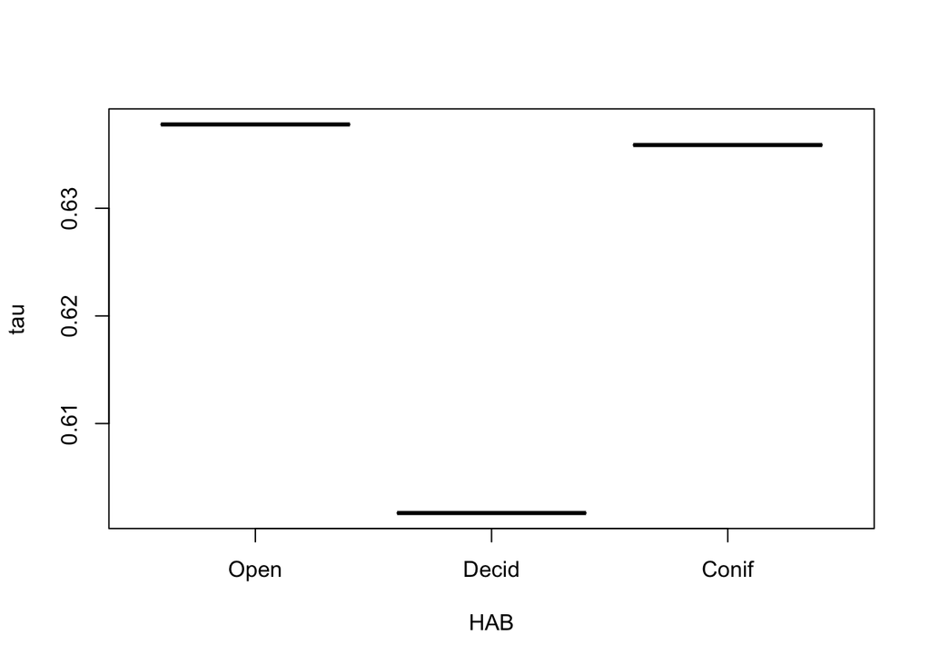

```r
tau <- exp(model.matrix(Mdis) %*% coef(Mdis))
boxplot(tau ~ HAB, x)
```

Finally, we calculate the correction factor for unlimited distances, and predict mean density:

```r
Apq <- pi * tau^2 * p * 1
x$ytot <- rowSums(Ydur)
mean(x$ytot / Apq)
```

```
## [1] 1.039206
```

Alternatively, we can use the log of the correction as an offset in log-linear models. This offset is called the QPAD offset:

```r
off <- log(Apq)
m <- glm(ytot ~ 1, data=x, offset=off, family=poisson)
exp(coef(m))
```

```
## (Intercept)
##    1.025481
```

## Exercise

Try distance sampling and density estimation for another species.

Fit multiple GLMs with QPAD offsets and covariates affecting density, interpret the results and the visualize responses.

Use `OBS` as predictor for `tau` and look at predicted EDRs. What is the practical issue with using observer as predictor?

Use `bSims::run_app("bsimsH")` to study the effects of the following factors on EDR ($\hat{\tau}$):

- spatial pattern of nest locations
- movement of individuals
- distance function misspecifications
- over/under counting
- distance measurement error

We need to talk about conditioning (1st event vs. 1st detection).

Use `bSims::run_app("bsimsHER")` to see how habitat related numeric and behavior and detection differences can bias estimates.

Next: Review QPAD, adding ARUs, looking into roadside data, etc.